# PEC 2: ANÁLISIS DE DATOS DE ULTRASECUENCIACIÓN

Andrea López

14/6/2020

En el estudio presentado a continuación se muestra un análisis de datos de contajes obtenidos mediante RNA-Seq para el estudio de genes diferencialmente expresados en muestras de tejido de tiroides con y sin infiltraciones. Además, los genes seleccionados están anotados y se realiza un breve análisis de significación biológica mediante términos GO.

En este estudio se analizan datos de expresión de diferentes genes mediante el análisis de datos obtenidos por RNA-Seq. En el estudio contamos con tres grupos de muestras de tiroides divididos según el tipo de infiltración que presenten: los tejidos sin infiltración (NIT), los tejidos con pequeñas infiltraciones focalizadas (SFI) y los tejidos con infiltraciones linfoides extensas (ELI). El objetivo es comparar los genes diferencialmente expresados entre estos grupos de muestras de tiroides para definir patrones de alteraciones de expresión con significancia biológica, en el caso de que existan.

La selección de datos se ha hecho en base a aquellas muestras con datos de tipo RNA seq (NGS) ya que el análisis a realizar será el de genes diferencialmente expresados con Bioconductor. El dataset lo he separado en función de los tres grupos definidos; ELI, NIT y SFI. El grupo ELI solo contaba con 8 muestras de RNA Seq (NGS) por lo que se han seleccionado todas y en cuanto a NIT y SFI, he hecho la asociación de números aleatorios con las muestras, de forma que 10 muestras aleatorias de cada uno de estos grupos han sido seleccionadas. Luego he unificado los datasets de los diferentes grupos en uno de datos seleccionados que, como se puede observar en la tabla, cumplen los requisitos del ejercicio.

```r
targets_RNAseq<-targets[targets$molecular_data_type=="RNA Seq (NGS)",]
table(targets_RNAseq$Group)
```

```
##
## ELI NIT SFI
##   8 119  24
```

```r
targets_ELI<-targets_RNAseq[targets_RNAseq$Group=="ELI",]
targets_NIT<-targets_RNAseq[targets_RNAseq$Group=="NIT",]
targets_SFI<-targets_RNAseq[targets_RNAseq$Group=="SFI",]

set.seed(123)
select_sampleNIT<-sample(119,10)
select_sampleSFI<-sample(24,10)

targets_NIT_sel<-targets_NIT[select_sampleNIT,]
targets_SFI_sel<-targets_SFI[select_sampleSFI,]

targets_RNAseqS<-rbind(targets_ELI,targets_NIT_sel,targets_SFI_sel)
table(targets_RNAseqS$Group)
```

```
##
## ELI NIT SFI
##   8  10  10
```

A continuación, se han asociado los datos de “counts” correspondientes a las muestras seleccionadas para proceder al preprocesado y filtraje.

Para que el análisis resulte más fácil, se han cambiado los nombres según el tipo de muestra que sean, pese a que en targets_RNAseqS se mantienen los originales para consultar (en el mismo orden).

```
## [1] "GTEX-111VG-0526-SM-5N9BW" "GTEX-11NV4-0626-SM-5N9BR"
## [3] "GTEX-11XUK-0226-SM-5EQLW" "GTEX-13NZ9-1126-SM-5MR37"
## [5] "GTEX-14AS3-0226-SM-5Q5B6" "GTEX-PLZ4-1226-SM-2I5FE"
## [7] "GTEX-R55G-0726-SM-2TC6J"  "GTEX-YJ89-0726-SM-5P9F7"
```

```
## [1] "GTEX-111VG-0526-SM-5N9BW" "GTEX-11NV4-0626-SM-5N9BR"
## [3] "GTEX-11XUK-0226-SM-5EQLW" "GTEX-13NZ9-1126-SM-5MR37"
## [5] "GTEX-14AS3-0226-SM-5Q5B6" "GTEX-PLZ4-1226-SM-2I5FE"
## [7] "GTEX-R55G-0726-SM-2TC6J"  "GTEX-YJ89-0726-SM-5P9F7"
```

```
## [1] "ELI 1" "ELI 2" "ELI 3" "ELI 4" "ELI 5" "ELI 6" "ELI 7" "ELI 8"
```

```
##  [1] "GTEX-1399R-0126-SM-5IFEV" "GTEX-RNOR-0926-SM-2TF56"
##  [3] "GTEX-13W46-0926-SM-5LU3T" "GTEX-11P7K-0226-SM-5986Z"
##  [5] "GTEX-14ICL-0426-SM-5RQJ3" "GTEX-13O61-0226-SM-5KM52"
##  [7] "GTEX-13VXT-0626-SM-5SIA1" "GTEX-13OW6-0726-SM-5L3FX"
##  [9] "GTEX-ZA64-0426-SM-5HL96"  "GTEX-ZYFG-0626-SM-5GZYA"
```

```
##  [1] "GTEX-1399R-0126-SM-5IFEV" "GTEX-RNOR-0926-SM-2TF56"
##  [3] "GTEX-13W46-0926-SM-5LU3T" "GTEX-11P7K-0226-SM-5986Z"
##  [5] "GTEX-14ICL-0426-SM-5RQJ3" "GTEX-13O61-0226-SM-5KM52"
##  [7] "GTEX-13VXT-0626-SM-5SIA1" "GTEX-13OW6-0726-SM-5L3FX"
##  [9] "GTEX-ZA64-0426-SM-5HL96"  "GTEX-ZYFG-0626-SM-5GZYA"
```

```
##  [1] "NIT 1"  "NIT 2"  "NIT 3"  "NIT 4"  "NIT 5"  "NIT 6"  "NIT 7"  "NIT 8"
##  [9] "NIT 9"  "NIT 10"
```

```
##  [1] "GTEX-WYVS-0326-SM-3NM9V"  "GTEX-11O72-2326-SM-5BC7H"
##  [3] "GTEX-S341-0226-SM-5S2VG"  "GTEX-12ZZX-1226-SM-5EGHS"
##  [5] "GTEX-11EQ9-0626-SM-5A5K1" "GTEX-12WSG-0226-SM-5EGIF"
##  [7] "GTEX-12584-0826-SM-5FQSK" "GTEX-12ZZY-0826-SM-5EQMT"
##  [9] "GTEX-TSE9-0626-SM-3DB8B"  "GTEX-13NYC-2426-SM-5MR3K"
```

```
##  [1] "GTEX-WYVS-0326-SM-3NM9V"  "GTEX-11O72-2326-SM-5BC7H"
##  [3] "GTEX-S341-0226-SM-5S2VG"  "GTEX-12ZZX-1226-SM-5EGHS"
##  [5] "GTEX-11EQ9-0626-SM-5A5K1" "GTEX-12WSG-0226-SM-5EGIF"
##  [7] "GTEX-12584-0826-SM-5FQSK" "GTEX-12ZZY-0826-SM-5EQMT"
##  [9] "GTEX-TSE9-0626-SM-3DB8B"  "GTEX-13NYC-2426-SM-5MR3K"
```

```
##  [1] "SFI 1"  "SFI 2"  "SFI 3"  "SFI 4"  "SFI 5"  "SFI 6"  "SFI 7"  "SFI 8"
##  [9] "SFI 9"  "SFI 10"
```

Los datos de contajes aportados pueden requerir su normalización y filtraje y para ello, se han representado varios gráficos que ilustran su distribución. A continuación encontramos el plot MDS o de escalamiento multidimensional que muestra como se distribuyen los datos en dos dimesiones. A simple vista, pese a que podemos agrupar algunos grupos en secciones características. No se observa ningún patrón claro de agrupación.

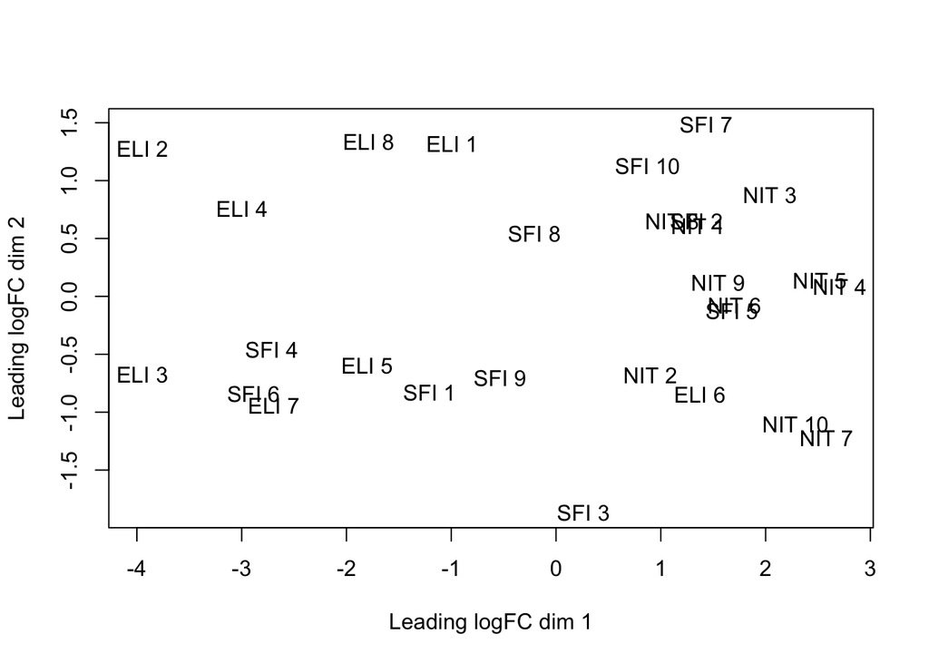

```r
group<-substr(colnames(counts_sel),1,3)
dgList <- DGEList(counts=counts_sel, genes=counts_data$ens, group = group)
plotMDS(dgList)
```

Para ilustrar los datos sin normalizar se adjunta también un boxplot.

```
## Using  as id variables
```

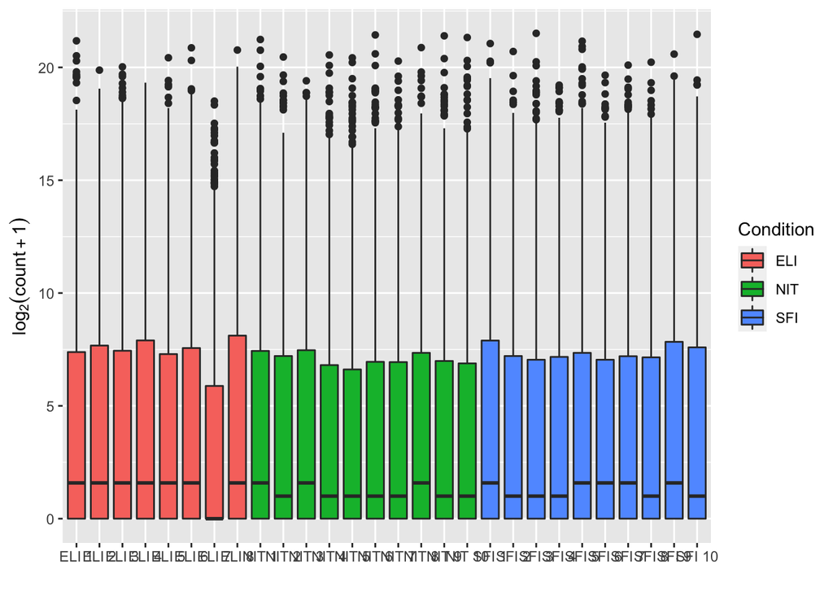

Como podemos observar, los datos no están normalizados y presentan diferencias de distribución. Para disminuir la variabilidad debida a factores casuales, a continuación se filtrarán y normalizarán los datos.

```
## [1] 56202    28
```

```
## [1] 19388    28
```

Para el filtraje, se eliminan aquellos genes cuyos contajes por millón sean inferiores a 1 y se mantienen todos aquellos mayores o iguales a 2. Con este filtro nos permitimos eliminar aquellos genes cuya secuenciación no haya resultado fructífera y que por lo tanto, no tendrán relevancia en un análisis de genes diferencialmente expresados. Como se puede observar, el número de genes después del filtraje pasa de los 56202 totales a 19388, reduciendo el número de genes a analizar en futuros pasos.

Una vez filtrados, los resultados de los genes seleccionados son normalizados mediante el método “Trimmed Mean of M-values” en el que las observaciones o muestras que tienen las expressiones medias más cerca de la media de todas las muestras son consideradas como “referencia” y todas las demás, muestras test. En este caso para cada muestra de test, el factor de escalada calculado para la normalización se basa en el peso de la media de los log ratio entre el test y la referencia, retirando de un conjunto de genes aquellos que están mucho más o mucho menos expressados y los que tienen mayores y menores log ratios.

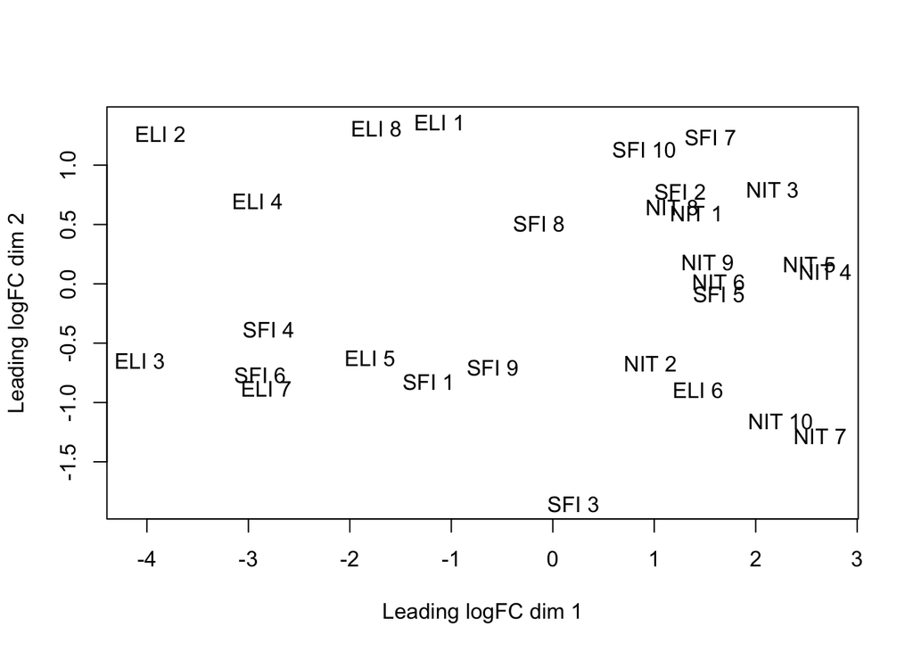

Como podemos observar, la distribución de los datos en dos dimensiones varía ligeramente con y sin normalización. Para ilustrarlo mejor, se adjuntan dos gráficos de intensidad en los que se muestran las diferencias entre los datos filtrados y normalizados, así como las diferencias de distribución de densidades de datos de contajes crudos y normalizados.

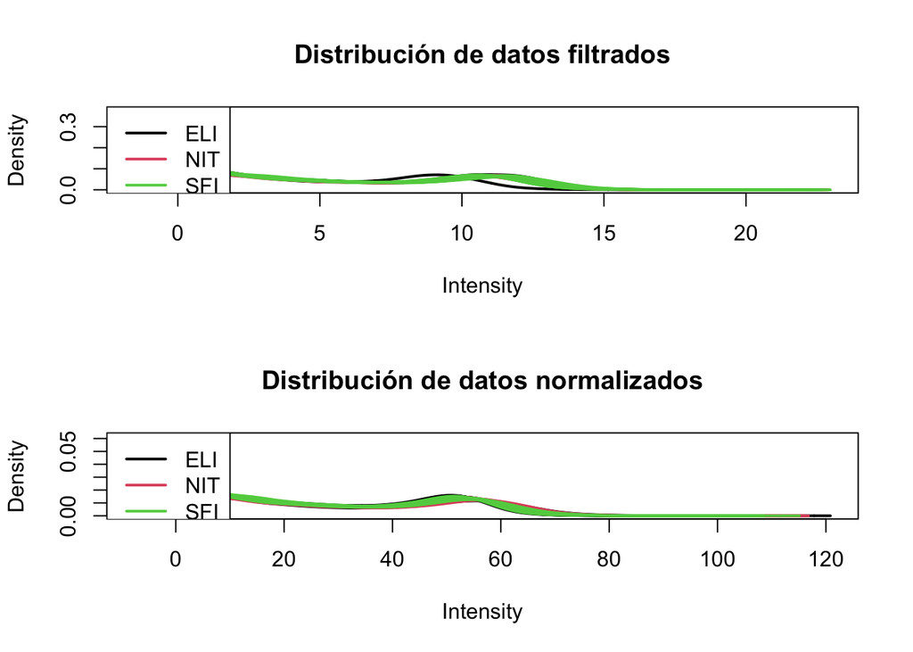

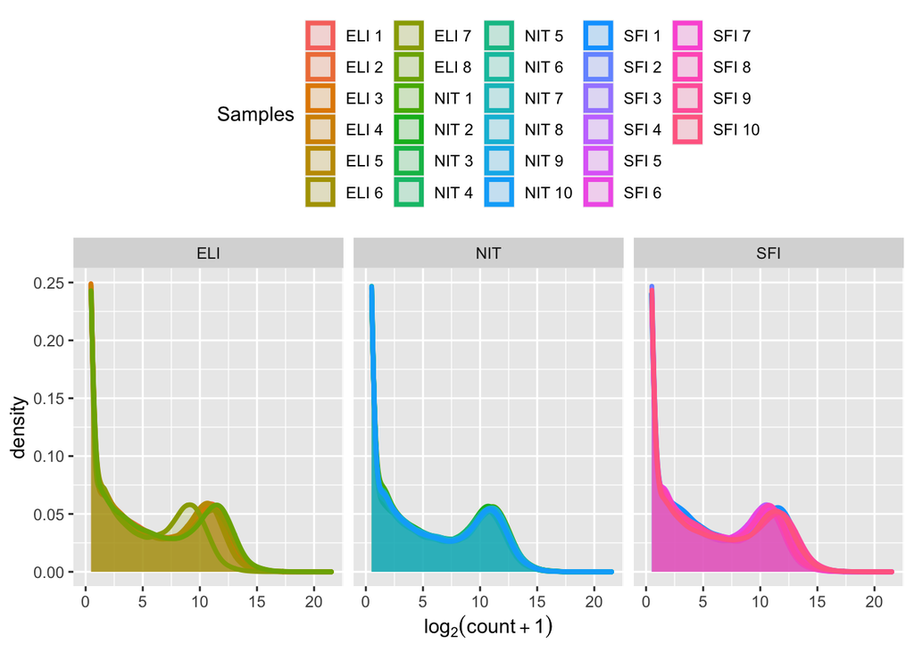

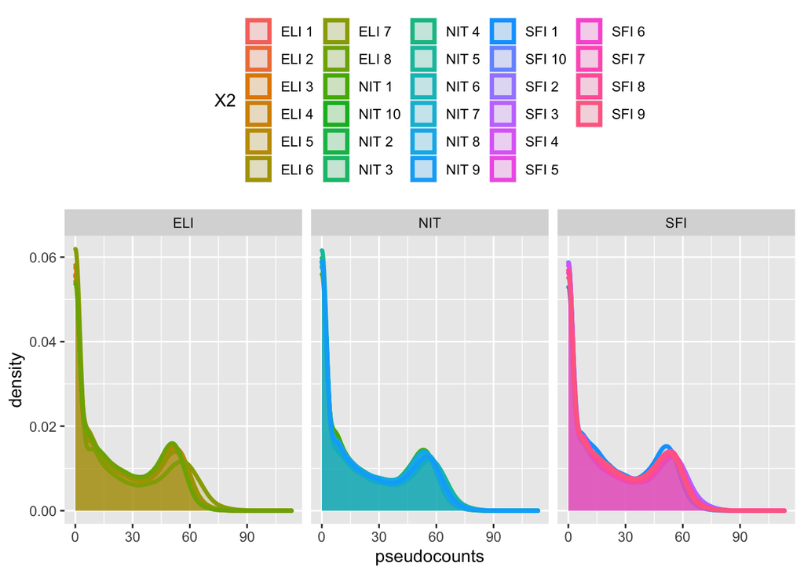

Una vez acabado el pre-procesado de los datos, se puede describir el modelo para definir los genes diferencialmente expresados.

El análisis de genes diferencialmente expresados lo he realizado con EdgeR, creando un objeto DGE a partir del cuál he realizado el análisis de genes diferencialmente expresados, especificando las tres comparaciones de interés, NIT vs ELI, NIT vs SFI y SFI vs ELI.

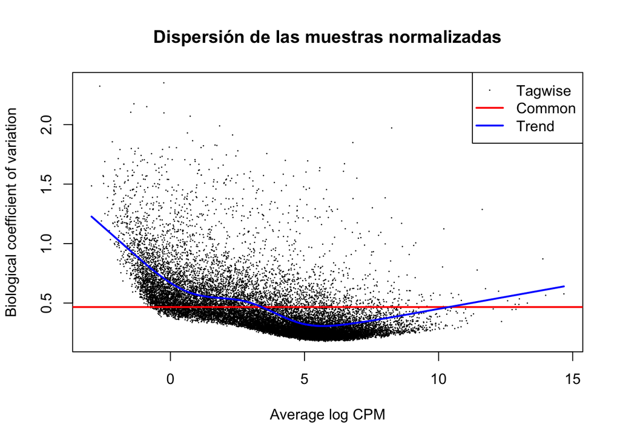

```r
#En un principio se define la matriz de diseño en la que se basará el análisis.
designMat <- model.matrix(~group)
#En función de esta matriz se hace un análisis de dispersiones gracias al cual obtenemos un gráfico de distribución de estas.
dgList <- estimateGLMCommonDisp(dgList, design=designMat)
dgList <- estimateGLMTrendedDisp(dgList, design=designMat)
dgList <- estimateGLMTagwiseDisp(dgList, design=designMat)
plotBCV(dgList, main= "Dispersión de las muestras normalizadas")
```

```r
#Una vez calculadas las dispersiones, se procede al modelo de análisis de genes diferencialmente expresados basado en la matriz de diseño.
fit<-glmFit(dgList,designMat)
```

En el gráfico se muestra la dispersión de las muestras normalizadas en el modelo, lo que nos muestra los valores más comunes así como la tendencia, valores entre los cuales de muestran diferencias, lo que demuestra que el modelo comprende genes diferencialmente expresados.

```
## Coefficient:  groupNIT
##                 genes     logFC   logCPM       LR       PValue          FDR
## 48230 ENSG00000167483 -7.239925 3.774220 88.17577 5.988910e-21 1.161130e-16
## 3379  ENSG00000143297 -8.019151 4.609100 81.79179 1.512053e-19 1.465785e-15
## 49407 ENSG00000104894 -4.347653 5.494380 80.31945 3.185183e-19 1.880011e-15
## 49477 ENSG00000269404 -6.540817 2.628305 79.93021 3.878710e-19 1.880011e-15
## 25262 ENSG00000245164 -5.030760 3.572782 78.70927 7.195723e-19 2.790214e-15
## 45681 ENSG00000007312 -4.444605 3.977842 76.93160 1.769827e-18 5.718899e-15
## 42101 ENSG00000177455 -8.318779 4.215559 76.19077 2.575423e-18 6.853243e-15
## 43621 ENSG00000083454 -6.414179 3.878615 76.00615 2.827829e-18 6.853243e-15
## 3725  ENSG00000188404 -4.038760 3.888494 74.53405 5.960148e-18 1.283948e-14
## 43771 ENSG00000072818 -3.681394 5.486126 73.39884 1.059283e-17 2.053737e-14
```

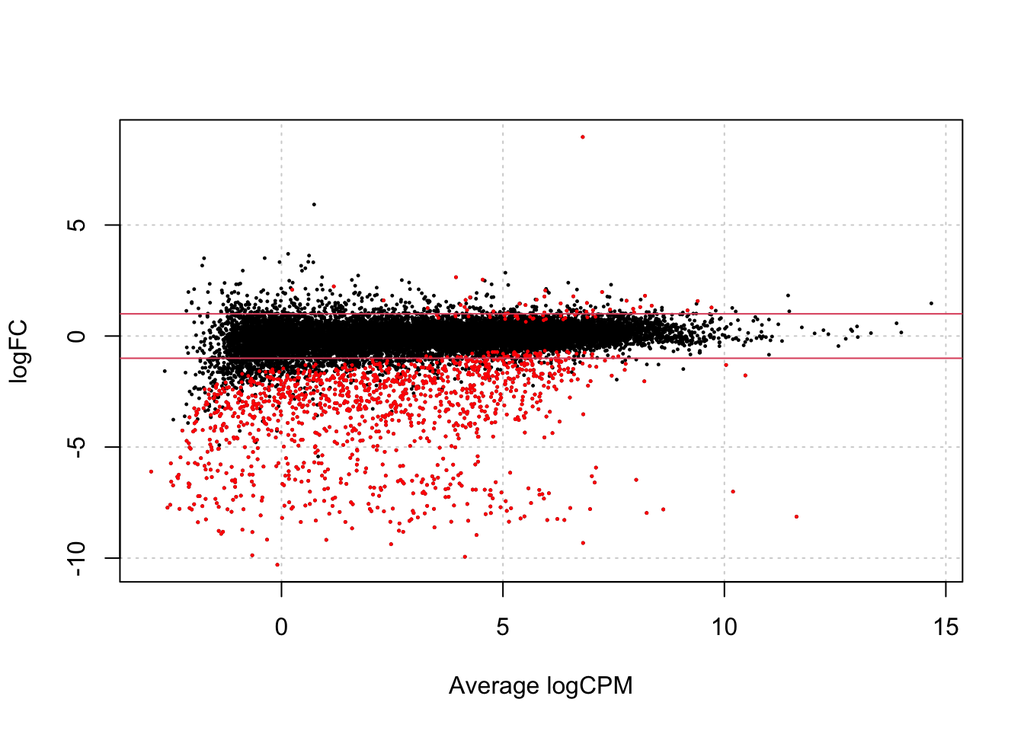

En la tabla se muestran los genes diferencialmente epxresados entre las muestras ELI y NIT con sus p-valores sin y con ajuste (FDR) y ordenados de más significativo a menos. En el gráfico se representa las veces que la expresión de un gen es mayor o menor en base a la referencia en función de la media de contajes por millón, lo que nos permite ver que algunos se expresan con “fold-changes” de entre -10 y 5, lo que nos muestra que a modo general que la expresión de los genes seleccionados es menor en las muestras NIT que ELI. Como podemos observar, las mayores diferencias se encuentran entre los genes cuyos contajes por millón son más bajos.

```
## Coefficient:  groupSFI
##                 genes     logFC   logCPM       LR       PValue          FDR
## 45499 ENSG00000265206 -3.948208 1.598581 49.19632 2.315850e-12 2.749481e-08
## 17962 ENSG00000111913 -2.308750 4.453070 48.35250 3.560898e-12 2.749481e-08
## 38705 ENSG00000100721 -6.993576 2.651936 47.60813 5.205218e-12 2.749481e-08
## 31641 ENSG00000068831 -2.656732 5.768233 47.43959 5.672543e-12 2.749481e-08
## 45681 ENSG00000007312 -3.254789 3.977842 45.57067 1.472298e-11 5.708982e-08
## 47726 ENSG00000104921 -5.149591 2.678307 42.84492 5.925564e-11 1.620990e-07
## 40218 ENSG00000247982 -3.015343 4.825448 42.77675 6.135706e-11 1.620990e-07
## 43702 ENSG00000161929 -2.880761 1.788777 42.60797 6.688631e-11 1.620990e-07
## 35404 ENSG00000122986 -2.154999 2.592503 41.99089 9.169964e-11 1.878057e-07
## 33354 ENSG00000111679 -1.698638 5.862422 41.88370 9.686700e-11 1.878057e-07
```

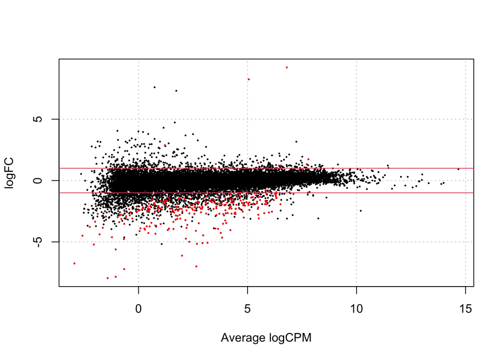

```
## Coefficient:  -1*groupNIT 1*groupSFI
##                 genes    logFC    logCPM       LR       PValue          FDR
## 3379  ENSG00000143297 5.781504  4.609100 52.74560 3.796737e-13 7.361115e-09
## 6695  ENSG00000211594 6.841402  5.634395 50.00989 1.529731e-12 1.482921e-08
## 6717  ENSG00000239951 6.751912  6.967605 47.96849 4.331238e-12 2.109597e-08
## 39069 ENSG00000253755 7.700656  6.227506 47.59976 5.227498e-12 2.109597e-08
## 39193 ENSG00000211959 7.205524  4.718070 47.52147 5.440470e-12 2.109597e-08
## 6725  ENSG00000244116 6.483556  3.704490 46.71526 8.208710e-12 2.652508e-08
## 39245 ENSG00000211973 6.908995  5.484819 46.17324 1.082455e-11 2.980691e-08
## 39075 ENSG00000211896 7.468970 11.627693 45.92304 1.229912e-11 2.980691e-08
## 39076 ENSG00000211897 6.420177  8.621137 45.08465 1.886990e-11 4.064996e-08
## 16760 ENSG00000170476 5.869610  4.699122 44.66791 2.334519e-11 4.526165e-08
```

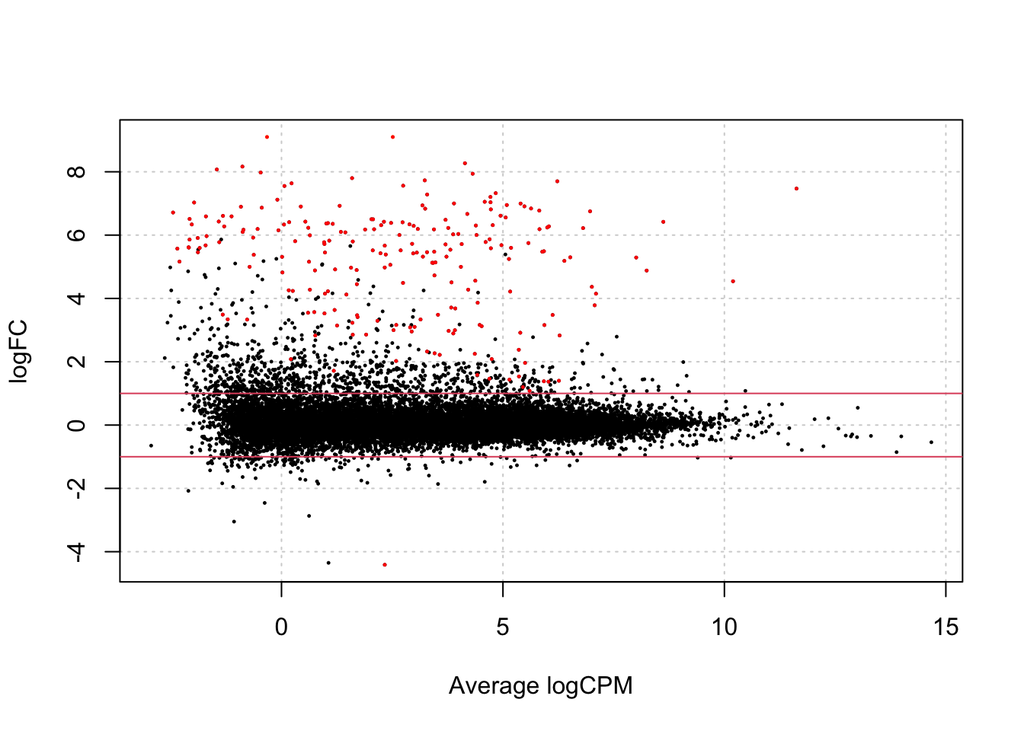

```
## Coefficient:  groupNIT
##                 genes     logFC   logCPM       LR       PValue          FDR
## 48230 ENSG00000167483 -7.239925 3.774220 88.17577 5.988910e-21 1.161130e-16
## 3379  ENSG00000143297 -8.019151 4.609100 81.79179 1.512053e-19 1.465785e-15
## 49407 ENSG00000104894 -4.347653 5.494380 80.31945 3.185183e-19 1.880011e-15
## 49477 ENSG00000269404 -6.540817 2.628305 79.93021 3.878710e-19 1.880011e-15
## 25262 ENSG00000245164 -5.030760 3.572782 78.70927 7.195723e-19 2.790214e-15
## 45681 ENSG00000007312 -4.444605 3.977842 76.93160 1.769827e-18 5.718899e-15
##          symbol    entrez
## 48230    NIBAN3    199786
## 3379      FCRL5     83416
## 49407      CD37       951
## 49477      SPIB      6689
## 25262 LINC00861 100130231
## 45681     CD79B       974
```

```
## Coefficient:  groupSFI
##                 genes     logFC   logCPM       LR       PValue          FDR
## 45499 ENSG00000265206 -3.948208 1.598581 49.19632 2.315850e-12 2.749481e-08
## 17962 ENSG00000111913 -2.308750 4.453070 48.35250 3.560898e-12 2.749481e-08
## 38705 ENSG00000100721 -6.993576 2.651936 47.60813 5.205218e-12 2.749481e-08
## 31641 ENSG00000068831 -2.656732 5.768233 47.43959 5.672543e-12 2.749481e-08
## 45681 ENSG00000007312 -3.254789 3.977842 45.57067 1.472298e-11 5.708982e-08
## 47726 ENSG00000104921 -5.149591 2.678307 42.84492 5.925564e-11 1.620990e-07
##        symbol entrez
## 45499    <NA>   <NA>
## 17962  RIPOR2   9750
## 38705   TCL1A   8115
## 31641 RASGRP2  10235
## 45681   CD79B    974
## 47726   FCER2   2208
```

[output not shown]

[output not shown]

|  | ID | Description | GeneRatio | BgRatio | pvalue | p.adjust | qvalue | geneID | Count |
| --- | --- | --- | --- | --- | --- | --- | --- | --- | --- |
| GO:0050853 | GO:0050853 | B cell receptor signaling pathway | 3/14 | 67/20536 | 1.177538e-05 | 0.003781448 | 0.002020544 | ENSG00000007312/ENSG00000177455/ENSG00000111679 | 3 |
| GO:0042113 | GO:0042113 | B cell activation | 4/14 | 249/20536 | 1.919517e-05 | 0.003781448 | 0.002020544 | ENSG00000007312/ENSG00000177455/ENSG00000111679/ENSG00000170476 | 4 |
| GO:0010522 | GO:0010522 | regulation of calcium ion transport into cytosol | 3/14 | 104/20536 | 4.410113e-05 | 0.004729007 | 0.002526854 | ENSG00000177455/ENSG00000083454/ENSG00000111679 | 3 |
| GO:0002920 | GO:0002920 | regulation of humoral immune response | 3/14 | 107/20536 | 4.801022e-05 | 0.004729007 | 0.002526854 | ENSG00000177455/ENSG00000104921/ENSG00000111679 | 3 |
| GO:0050864 | GO:0050864 | regulation of B cell activation | 3/14 | 120/20536 | 6.757610e-05 | 0.005324997 | 0.002845309 | ENSG00000177455/ENSG00000111679/ENSG00000170476 | 3 |
| GO:0030183 | GO:0030183 | B cell differentiation | 3/14 | 136/20536 | 9.803107e-05 | 0.006437374 | 0.003439687 | ENSG00000007312/ENSG00000177455/ENSG00000111679 | 3 |
| GO:0002923 | GO:0002923 | regulation of humoral immune response mediated by circulating immunoglobulin | 2/14 | 25/20536 | 1.283188e-04 | 0.007222515 | 0.003859212 | ENSG00000104921/ENSG00000111679 | 2 |
| GO:0016064 | GO:0016064 | immunoglobulin mediated immune response | 3/14 | 159/20536 | 1.557109e-04 | 0.007345566 | 0.003924962 | ENSG00000177455/ENSG00000104921/ENSG00000111679 | 3 |
| GO:0019724 | GO:0019724 | B cell mediated immunity | 3/14 | 169/20536 | 1.864357e-04 | 0.007345566 | 0.003924962 | ENSG00000177455/ENSG00000104921/ENSG00000111679 | 3 |
| GO:0060402 | GO:0060402 | calcium ion transport into cytosol | 3/14 | 169/20536 | 1.864357e-04 | 0.007345566 | 0.003924962 | ENSG00000177455/ENSG00000083454/ENSG00000111679 | 3 |

[output cut: 384 more lines]

|  | ID | Description | GeneRatio | BgRatio | pvalue | p.adjust | qvalue | geneID | Count |
| --- | --- | --- | --- | --- | --- | --- | --- | --- | --- |
| GO:0010524 | GO:0010524 | positive regulation of calcium ion transport into cytosol | 2/6 | 54/20536 | 0.0001011151 | 0.006784535 | 0.002298451 | ENSG00000177455/ENSG00000083454 | 2 |
| GO:0050853 | GO:0050853 | B cell receptor signaling pathway | 2/6 | 67/20536 | 0.0001559663 | 0.006784535 | 0.002298451 | ENSG00000007312/ENSG00000177455 | 2 |
| GO:0010522 | GO:0010522 | regulation of calcium ion transport into cytosol | 2/6 | 104/20536 | 0.0003760038 | 0.010904109 | 0.003694072 | ENSG00000177455/ENSG00000083454 | 2 |
| GO:0051928 | GO:0051928 | positive regulation of calcium ion transport | 2/6 | 134/20536 | 0.0006231347 | 0.011166944 | 0.003783115 | ENSG00000177455/ENSG00000083454 | 2 |
| GO:0030183 | GO:0030183 | B cell differentiation | 2/6 | 136/20536 | 0.0006417784 | 0.011166944 | 0.003783115 | ENSG00000007312/ENSG00000177455 | 2 |
| GO:0060402 | GO:0060402 | calcium ion transport into cytosol | 2/6 | 169/20536 | 0.0009881922 | 0.014328787 | 0.004854277 | ENSG00000177455/ENSG00000083454 | 2 |
| GO:0060401 | GO:0060401 | cytosolic calcium ion transport | 2/6 | 191/20536 | 0.0012594678 | 0.015653385 | 0.005303022 | ENSG00000177455/ENSG00000083454 | 2 |
| GO:0042113 | GO:0042113 | B cell activation | 2/6 | 249/20536 | 0.0021269893 | 0.023131008 | 0.007836276 | ENSG00000007312/ENSG00000177455 | 2 |
| GO:0051924 | GO:0051924 | regulation of calcium ion transport | 2/6 | 288/20536 | 0.0028325467 | 0.025491110 | 0.008635827 | ENSG00000177455/ENSG00000083454 | 2 |
| GO:0043270 | GO:0043270 | positive regulation of ion transport | 2/6 | 293/20536 | 0.0029300127 | 0.025491110 | 0.008635827 | ENSG00000177455/ENSG00000083454 | 2 |

[output cut: 77 more lines]

|  | ID | Description | GeneRatio | BgRatio | pvalue | p.adjust | qvalue | geneID | Count |
| --- | --- | --- | --- | --- | --- | --- | --- | --- | --- |
| GO:0002923 | GO:0002923 | regulation of humoral immune response mediated by circulating immunoglobulin | 2/8 | 25/20536 | 3.965998e-05 | 0.01328609 | 0.006512586 | ENSG00000104921/ENSG00000111679 | 2 |
| GO:0050853 | GO:0050853 | B cell receptor signaling pathway | 2/8 | 67/20536 | 2.899109e-04 | 0.02424197 | 0.011882948 | ENSG00000007312/ENSG00000111679 | 2 |
| GO:0002712 | GO:0002712 | regulation of B cell mediated immunity | 2/8 | 72/20536 | 3.348214e-04 | 0.02424197 | 0.011882948 | ENSG00000104921/ENSG00000111679 | 2 |
| GO:0002889 | GO:0002889 | regulation of immunoglobulin mediated immune response | 2/8 | 72/20536 | 3.348214e-04 | 0.02424197 | 0.011882948 | ENSG00000104921/ENSG00000111679 | 2 |
| GO:0051260 | GO:0051260 | protein homooligomerization | 3/8 | 415/20536 | 4.254425e-04 | 0.02424197 | 0.011882948 | ENSG00000111913/ENSG00000100721/ENSG00000007312 | 3 |
| GO:0002455 | GO:0002455 | humoral immune response mediated by circulating immunoglobulin | 2/8 | 82/20536 | 4.341846e-04 | 0.02424197 | 0.011882948 | ENSG00000104921/ENSG00000111679 | 2 |
| GO:0002920 | GO:0002920 | regulation of humoral immune response | 2/8 | 107/20536 | 7.378153e-04 | 0.03530973 | 0.017308148 | ENSG00000104921/ENSG00000111679 | 2 |
| GO:0030183 | GO:0030183 | B cell differentiation | 2/8 | 136/20536 | 1.187609e-03 | 0.04615756 | 0.022625542 | ENSG00000007312/ENSG00000111679 | 2 |
| GO:0050868 | GO:0050868 | negative regulation of T cell activation | 2/8 | 139/20536 | 1.240054e-03 | 0.04615756 | 0.022625542 | ENSG00000111913/ENSG00000111679 | 2 |
| GO:1903038 | GO:1903038 | negative regulation of leukocyte cell-cell adhesion | 2/8 | 156/20536 | 1.557981e-03 | 0.04826631 | 0.023659212 | ENSG00000111913/ENSG00000111679 | 2 |

[output cut: 325 more lines]

|  | ID | Description | GeneRatio | BgRatio | pvalue | p.adjust | qvalue | geneID | Count |
| --- | --- | --- | --- | --- | --- | --- | --- | --- | --- |
| GO:0033622 | GO:0033622 | integrin activation | 1/1 | 22/20536 | 0.001071289 | 0.01666991 | NA | ENSG00000170476 | 1 |
| GO:0002639 | GO:0002639 | positive regulation of immunoglobulin production | 1/1 | 50/20536 | 0.002434749 | 0.01666991 | NA | ENSG00000170476 | 1 |
| GO:0030888 | GO:0030888 | regulation of B cell proliferation | 1/1 | 64/20536 | 0.003116478 | 0.01666991 | NA | ENSG00000170476 | 1 |
| GO:0046626 | GO:0046626 | regulation of insulin receptor signaling pathway | 1/1 | 66/20536 | 0.003213868 | 0.01666991 | NA | ENSG00000170476 | 1 |
| GO:1900076 | GO:1900076 | regulation of cellular response to insulin stimulus | 1/1 | 74/20536 | 0.003603428 | 0.01666991 | NA | ENSG00000170476 | 1 |
| GO:0002637 | GO:0002637 | regulation of immunoglobulin production | 1/1 | 79/20536 | 0.003846903 | 0.01666991 | NA | ENSG00000170476 | 1 |
| GO:0042100 | GO:0042100 | B cell proliferation | 1/1 | 99/20536 | 0.004820802 | 0.01790584 | NA | ENSG00000170476 | 1 |
| GO:0050864 | GO:0050864 | regulation of B cell activation | 1/1 | 120/20536 | 0.005843397 | 0.01814699 | NA | ENSG00000170476 | 1 |
| GO:0002377 | GO:0002377 | immunoglobulin production | 1/1 | 129/20536 | 0.006281652 | 0.01814699 | NA | ENSG00000170476 | 1 |
| GO:0008286 | GO:0008286 | insulin receptor signaling pathway | 1/1 | 151/20536 | 0.007352941 | 0.01899104 | NA | ENSG00000170476 | 1 |

[output cut: 16 more lines]

Los resultados de las tres comparaciones estudiadas: tejidos sin infiltración (NIT) vs tejidos con infiltración leucocitaria extensa (ELI), tejidos con infiltración focal pequeña (SFI) vs tejidos con infiltración leucocitaria extensa (ELI) y tejidos sin infiltración (NIT) vs tejidos con infiltración focal pequeña, nos muestran grupos de genes diferencialmente expresados cuyos procesos biológicos están, en gran parte, relacionados entre ellos.

A nivel de análisis de significancia biológica general, me parece interesante recalcar los resultados de la siguiente tabla:

|  | ID | Description | GeneRatio | BgRatio | pvalue | p.adjust | qvalue | geneID | Count |
| --- | --- | --- | --- | --- | --- | --- | --- | --- | --- |
| GO:0050853 | GO:0050853 | B cell receptor signaling pathway | 3/14 | 67/20536 | 1.177538e-05 | 0.003781448 | 0.002020544 | ENSG00000007312/ENSG00000177455/ENSG00000111679 | 3 |
| GO:0042113 | GO:0042113 | B cell activation | 4/14 | 249/20536 | 1.919517e-05 | 0.003781448 | 0.002020544 | ENSG00000007312/ENSG00000177455/ENSG00000111679/ENSG00000170476 | 4 |
| GO:0010522 | GO:0010522 | regulation of calcium ion transport into cytosol | 3/14 | 104/20536 | 4.410113e-05 | 0.004729007 | 0.002526854 | ENSG00000177455/ENSG00000083454/ENSG00000111679 | 3 |
| GO:0002920 | GO:0002920 | regulation of humoral immune response | 3/14 | 107/20536 | 4.801022e-05 | 0.004729007 | 0.002526854 | ENSG00000177455/ENSG00000104921/ENSG00000111679 | 3 |
| GO:0050864 | GO:0050864 | regulation of B cell activation | 3/14 | 120/20536 | 6.757610e-05 | 0.005324997 | 0.002845309 | ENSG00000177455/ENSG00000111679/ENSG00000170476 | 3 |
| GO:0030183 | GO:0030183 | B cell differentiation | 3/14 | 136/20536 | 9.803107e-05 | 0.006437374 | 0.003439687 | ENSG00000007312/ENSG00000177455/ENSG00000111679 | 3 |
| GO:0002923 | GO:0002923 | regulation of humoral immune response mediated by circulating immunoglobulin | 2/14 | 25/20536 | 1.283188e-04 | 0.007222515 | 0.003859212 | ENSG00000104921/ENSG00000111679 | 2 |
| GO:0016064 | GO:0016064 | immunoglobulin mediated immune response | 3/14 | 159/20536 | 1.557109e-04 | 0.007345566 | 0.003924962 | ENSG00000177455/ENSG00000104921/ENSG00000111679 | 3 |
| GO:0019724 | GO:0019724 | B cell mediated immunity | 3/14 | 169/20536 | 1.864357e-04 | 0.007345566 | 0.003924962 | ENSG00000177455/ENSG00000104921/ENSG00000111679 | 3 |
| GO:0060402 | GO:0060402 | calcium ion transport into cytosol | 3/14 | 169/20536 | 1.864357e-04 | 0.007345566 | 0.003924962 | ENSG00000177455/ENSG00000083454/ENSG00000111679 | 3 |

[output cut: 384 more lines]

Como podemos observar, la mayoría de los genes seleccionados como diferencialmente expresados en todas las comparaciones están relacionados directamente con la activación de funciones relacionadas con el sistema immuno como la vía del receptor de células B, su activación, diferenciación o regulación de la inmunidad humoral, lo que tiene sentido dadas las muestras utilizadas para el estudio.

```
## Coefficient:  groupNIT
##                 genes     logFC   logCPM       LR       PValue          FDR
## 48230 ENSG00000167483 -7.239925 3.774220 88.17577 5.988910e-21 1.161130e-16
## 3379  ENSG00000143297 -8.019151 4.609100 81.79179 1.512053e-19 1.465785e-15
## 49407 ENSG00000104894 -4.347653 5.494380 80.31945 3.185183e-19 1.880011e-15
## 49477 ENSG00000269404 -6.540817 2.628305 79.93021 3.878710e-19 1.880011e-15
## 25262 ENSG00000245164 -5.030760 3.572782 78.70927 7.195723e-19 2.790214e-15
## 45681 ENSG00000007312 -4.444605 3.977842 76.93160 1.769827e-18 5.718899e-15
##          symbol    entrez
## 48230    NIBAN3    199786
## 3379      FCRL5     83416
## 49407      CD37       951
## 49477      SPIB      6689
## 25262 LINC00861 100130231
## 45681     CD79B       974
```

|  | ID | Description | GeneRatio | BgRatio | pvalue | p.adjust | qvalue | geneID | Count |
| --- | --- | --- | --- | --- | --- | --- | --- | --- | --- |
| GO:0010524 | GO:0010524 | positive regulation of calcium ion transport into cytosol | 2/6 | 54/20536 | 0.0001011151 | 0.006784535 | 0.002298451 | ENSG00000177455/ENSG00000083454 | 2 |
| GO:0050853 | GO:0050853 | B cell receptor signaling pathway | 2/6 | 67/20536 | 0.0001559663 | 0.006784535 | 0.002298451 | ENSG00000007312/ENSG00000177455 | 2 |
| GO:0010522 | GO:0010522 | regulation of calcium ion transport into cytosol | 2/6 | 104/20536 | 0.0003760038 | 0.010904109 | 0.003694072 | ENSG00000177455/ENSG00000083454 | 2 |
| GO:0051928 | GO:0051928 | positive regulation of calcium ion transport | 2/6 | 134/20536 | 0.0006231347 | 0.011166944 | 0.003783115 | ENSG00000177455/ENSG00000083454 | 2 |
| GO:0030183 | GO:0030183 | B cell differentiation | 2/6 | 136/20536 | 0.0006417784 | 0.011166944 | 0.003783115 | ENSG00000007312/ENSG00000177455 | 2 |
| GO:0060402 | GO:0060402 | calcium ion transport into cytosol | 2/6 | 169/20536 | 0.0009881922 | 0.014328787 | 0.004854277 | ENSG00000177455/ENSG00000083454 | 2 |
| GO:0060401 | GO:0060401 | cytosolic calcium ion transport | 2/6 | 191/20536 | 0.0012594678 | 0.015653385 | 0.005303022 | ENSG00000177455/ENSG00000083454 | 2 |
| GO:0042113 | GO:0042113 | B cell activation | 2/6 | 249/20536 | 0.0021269893 | 0.023131008 | 0.007836276 | ENSG00000007312/ENSG00000177455 | 2 |
| GO:0051924 | GO:0051924 | regulation of calcium ion transport | 2/6 | 288/20536 | 0.0028325467 | 0.025491110 | 0.008635827 | ENSG00000177455/ENSG00000083454 | 2 |
| GO:0043270 | GO:0043270 | positive regulation of ion transport | 2/6 | 293/20536 | 0.0029300127 | 0.025491110 | 0.008635827 | ENSG00000177455/ENSG00000083454 | 2 |

[output cut: 77 more lines]

En cuanto a la siguiente comparación, de muestras con pequeñas y extensas infiltraciones observamos que la magnitud de la diferencia no es tan superior como en la anterior comparación así como el nivel de significatividad estadística de estas. De forma similar, el análisis de significancia biológica nos muestra cambios también a nivel de sistema immune, esta vez más centrados en la regulación de la respuesta humanoral, así como las células B, T y adhesión leucocitaria.

```
## Coefficient:  groupSFI
##                 genes     logFC   logCPM       LR       PValue          FDR
## 45499 ENSG00000265206 -3.948208 1.598581 49.19632 2.315850e-12 2.749481e-08
## 17962 ENSG00000111913 -2.308750 4.453070 48.35250 3.560898e-12 2.749481e-08
## 38705 ENSG00000100721 -6.993576 2.651936 47.60813 5.205218e-12 2.749481e-08
## 31641 ENSG00000068831 -2.656732 5.768233 47.43959 5.672543e-12 2.749481e-08
## 45681 ENSG00000007312 -3.254789 3.977842 45.57067 1.472298e-11 5.708982e-08
## 47726 ENSG00000104921 -5.149591 2.678307 42.84492 5.925564e-11 1.620990e-07
##        symbol entrez
## 45499    <NA>   <NA>
## 17962  RIPOR2   9750
## 38705   TCL1A   8115
## 31641 RASGRP2  10235
## 45681   CD79B    974
## 47726   FCER2   2208
```

|  | ID | Description | GeneRatio | BgRatio | pvalue | p.adjust | qvalue | geneID | Count |
| --- | --- | --- | --- | --- | --- | --- | --- | --- | --- |
| GO:0002923 | GO:0002923 | regulation of humoral immune response mediated by circulating immunoglobulin | 2/8 | 25/20536 | 3.965998e-05 | 0.01328609 | 0.006512586 | ENSG00000104921/ENSG00000111679 | 2 |
| GO:0050853 | GO:0050853 | B cell receptor signaling pathway | 2/8 | 67/20536 | 2.899109e-04 | 0.02424197 | 0.011882948 | ENSG00000007312/ENSG00000111679 | 2 |
| GO:0002712 | GO:0002712 | regulation of B cell mediated immunity | 2/8 | 72/20536 | 3.348214e-04 | 0.02424197 | 0.011882948 | ENSG00000104921/ENSG00000111679 | 2 |
| GO:0002889 | GO:0002889 | regulation of immunoglobulin mediated immune response | 2/8 | 72/20536 | 3.348214e-04 | 0.02424197 | 0.011882948 | ENSG00000104921/ENSG00000111679 | 2 |
| GO:0051260 | GO:0051260 | protein homooligomerization | 3/8 | 415/20536 | 4.254425e-04 | 0.02424197 | 0.011882948 | ENSG00000111913/ENSG00000100721/ENSG00000007312 | 3 |
| GO:0002455 | GO:0002455 | humoral immune response mediated by circulating immunoglobulin | 2/8 | 82/20536 | 4.341846e-04 | 0.02424197 | 0.011882948 | ENSG00000104921/ENSG00000111679 | 2 |
| GO:0002920 | GO:0002920 | regulation of humoral immune response | 2/8 | 107/20536 | 7.378153e-04 | 0.03530973 | 0.017308148 | ENSG00000104921/ENSG00000111679 | 2 |
| GO:0030183 | GO:0030183 | B cell differentiation | 2/8 | 136/20536 | 1.187609e-03 | 0.04615756 | 0.022625542 | ENSG00000007312/ENSG00000111679 | 2 |
| GO:0050868 | GO:0050868 | negative regulation of T cell activation | 2/8 | 139/20536 | 1.240054e-03 | 0.04615756 | 0.022625542 | ENSG00000111913/ENSG00000111679 | 2 |
| GO:1903038 | GO:1903038 | negative regulation of leukocyte cell-cell adhesion | 2/8 | 156/20536 | 1.557981e-03 | 0.04826631 | 0.023659212 | ENSG00000111913/ENSG00000111679 | 2 |

[output cut: 325 more lines]

Por último, la comparación entre muestras sin infiltraciones así como con infiltraciones pequeñas focales muestra cambios de magnitud más parecidas al primero, es decir, en general a nivel de expresión génica difieren más los tejidos sin infiltraciones con los infiltrados, independientemente del tamaño de estas, que los tejidos con infiltraciones entre ellos. En este caso los cambios también están asociados con procesos del sistema immune así como regulación de la proliferación y activación de células B y producción de immunoglobulinas.

[output not shown]

|  | ID | Description | GeneRatio | BgRatio | pvalue | p.adjust | qvalue | geneID | Count |
| --- | --- | --- | --- | --- | --- | --- | --- | --- | --- |
| GO:0033622 | GO:0033622 | integrin activation | 1/1 | 22/20536 | 0.001071289 | 0.01666991 | NA | ENSG00000170476 | 1 |
| GO:0002639 | GO:0002639 | positive regulation of immunoglobulin production | 1/1 | 50/20536 | 0.002434749 | 0.01666991 | NA | ENSG00000170476 | 1 |
| GO:0030888 | GO:0030888 | regulation of B cell proliferation | 1/1 | 64/20536 | 0.003116478 | 0.01666991 | NA | ENSG00000170476 | 1 |
| GO:0046626 | GO:0046626 | regulation of insulin receptor signaling pathway | 1/1 | 66/20536 | 0.003213868 | 0.01666991 | NA | ENSG00000170476 | 1 |
| GO:1900076 | GO:1900076 | regulation of cellular response to insulin stimulus | 1/1 | 74/20536 | 0.003603428 | 0.01666991 | NA | ENSG00000170476 | 1 |
| GO:0002637 | GO:0002637 | regulation of immunoglobulin production | 1/1 | 79/20536 | 0.003846903 | 0.01666991 | NA | ENSG00000170476 | 1 |
| GO:0042100 | GO:0042100 | B cell proliferation | 1/1 | 99/20536 | 0.004820802 | 0.01790584 | NA | ENSG00000170476 | 1 |
| GO:0050864 | GO:0050864 | regulation of B cell activation | 1/1 | 120/20536 | 0.005843397 | 0.01814699 | NA | ENSG00000170476 | 1 |
| GO:0002377 | GO:0002377 | immunoglobulin production | 1/1 | 129/20536 | 0.006281652 | 0.01814699 | NA | ENSG00000170476 | 1 |
| GO:0008286 | GO:0008286 | insulin receptor signaling pathway | 1/1 | 151/20536 | 0.007352941 | 0.01899104 | NA | ENSG00000170476 | 1 |

[output cut: 16 more lines]

Como discusión me gustaría añadir simplemente que el estudio me ha parecido muy completo pese a que yo no he sabido sacarle todo el provecho posible. Me he encontrado dificultades a la hora de seleccionar todo el conjunto de genes diferencialmente expresados de cada comparación, así como un análisis más extenso de estos, conocimiento que espero poder seguir adquiriendo aún acabada la asignatura. A nivel de aspectos generales de la práctica, creo que los datos del estudio son suficientemente claros y bien representados como para llevar a cabo el análisis sin mayor problemática.

Enlace a repositorio: https://github.com/andrealopmar/ADO-PEC2.git

```r
#Cargar datos
library(readr)
targets <- read_csv("~/Downloads/archivos targets y counts/targets.csv")
counts <- read_delim("~/Downloads/archivos targets y counts/counts.csv",
    ";", escape_double = FALSE, trim_ws = TRUE)
```

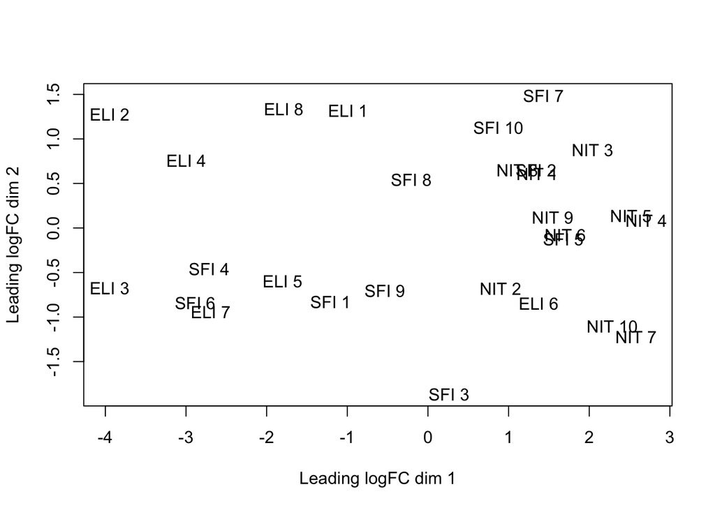

```r
#Selección de datos
targets_RNAseq<-targets[targets$molecular_data_type=="RNA Seq (NGS)",]
table(targets_RNAseq$Group)

targets_ELI<-targets_RNAseq[targets_RNAseq$Group=="ELI",]
targets_NIT<-targets_RNAseq[targets_RNAseq$Group=="NIT",]
targets_SFI<-targets_RNAseq[targets_RNAseq$Group=="SFI",]

set.seed(123)
select_sampleNIT<-sample(119,10)
select_sampleSFI<-sample(24,10)

targets_NIT_sel<-targets_NIT[select_sampleNIT,]
targets_SFI_sel<-targets_SFI[select_sampleSFI,]

targets_RNAseqS<-rbind(targets_ELI,targets_NIT_sel,targets_SFI_sel)
table(targets_RNAseqS$Group)

#Asociar targets y counts
library(dplyr)
counts_sel<-dplyr::select(counts,contains(targets_RNAseqS$Sample_Name))
counts_data<-cbind(counts$X1,counts_sel)
names(counts_data)[1]<-paste("ens")
counts_data$ens<-substr(counts_data$ens,1,15)

#Change names
targets_ELI$Sample_Name
colnames(counts_data)[2:9]
colnames(counts_data)[2:9]<-paste("ELI",1:8)
colnames(counts_data)[2:9]

names_NIT_sel<-targets_NIT_sel$Sample_Name
names_NIT_sel
colnames(counts_data)[10:19]
colnames(counts_data)[10:19]<-paste("NIT",1:10)
colnames(counts_data)[10:19]

names_SFI_sel<-targets_SFI_sel$Sample_Name
names_SFI_sel
colnames(counts_data)[20:29]
colnames(counts_data)[20:29]<-paste("SFI", 1:10)
colnames(counts_data)[20:29]

colnames(counts_sel)[1:8]<-paste("ELI",1:8)
colnames(counts_sel)[9:18]<-paste("NIT",1:10)
colnames(counts_sel)[19:28]<-paste("SFI", 1:10)

#Definir dataset
group<-substr(colnames(counts_sel),1,3)
dgList <- DGEList(counts=counts_sel, genes=counts_data$ens, group = group)
plotMDS(dgList)
```

```r
#Boxplot
library(reshape)
library(ggplot2)

pseudoCount<-log2(counts_sel + 1)
counts_logS<- melt(pseudoCount, variable_name = "Samples")
```

```
## Using  as id variables
```

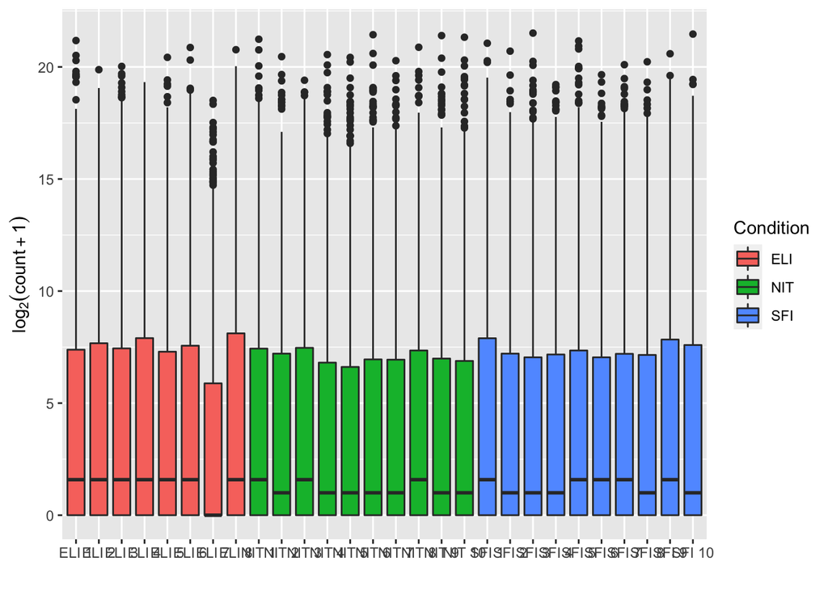

```r
df.countslog<-data.frame(counts_logS, Condition = substr(counts_logS$Samples, 1, 3))
ggplot(df.countslog, aes(x = Samples, y = value, fill = Condition)) + geom_boxplot() + xlab("") +
ylab(expression(log[2](count + 1)))
```

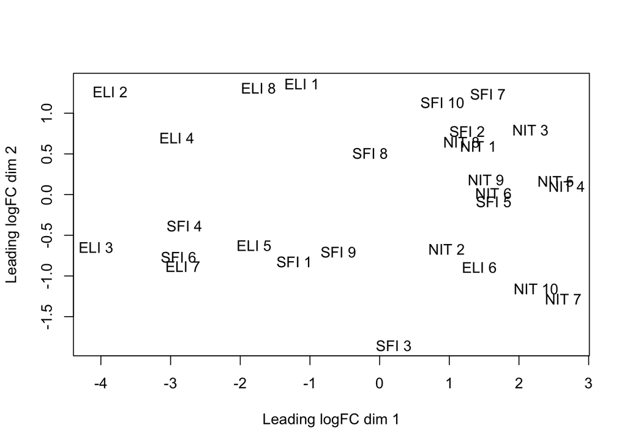

```r
#Filtraje
countsPerMillion <- cpm(dgList)
countCheck <- countsPerMillion > 1
dim(dgList)
keep <- which(rowSums(countCheck) >= 2)
dgList <- dgList[keep,]
dim(cpm(dgList))

#Normalización
dgList <- calcNormFactors(dgList, method="TMM")
plotMDS(dgList)
```

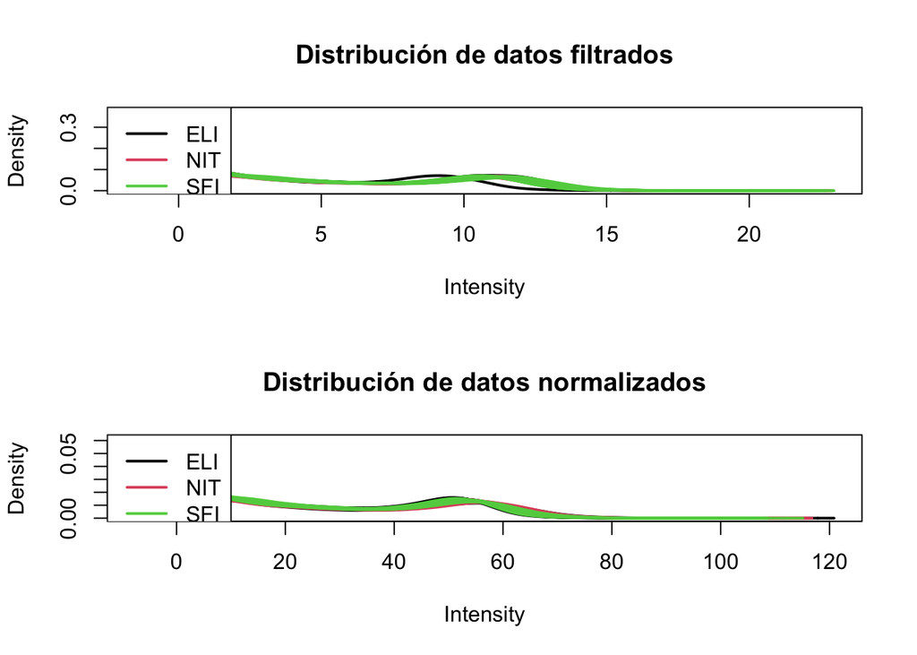

```r
#Plot density
library(edgeR)
library(limma)
keep<- rowSums(counts_sel) > 0
counts_filt<-pseudoCount[keep, ]
counts_norm<-cpm(counts_filt, normalized.lib.sized= TRUE)
par(mfrow=c(2,1))
plotDensities(counts_filt, group = substr(colnames(counts_norm),1,3), main = "Distribución de datos filtrados")
plotDensities(counts_norm, group = substr(colnames(counts_norm),1,3), main= "Distribución de datos normalizados")
```

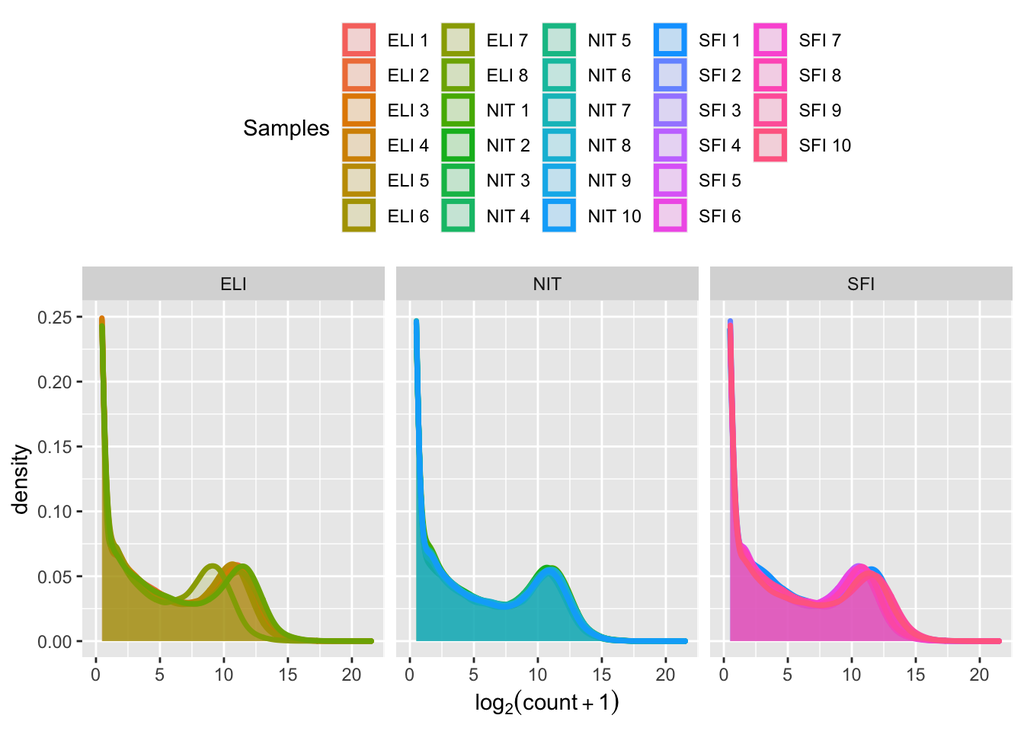

```r
#Density norm
df.norm<- melt(counts_norm, variable_name = "X2")
df.norm<-data.frame(df.norm, Condition = substr(df.norm$X2, 1, 3))
par(mfrow=c(2,1))
ggplot(df.countslog, aes(x = value, colour = Samples, fill = Samples, main= "Distribución de datos crudos")) + ylim(c(0, 0.25)) +
geom_density(alpha = 0.2, size = 1.25) + facet_wrap(~ Condition) +
theme(legend.position = "top") + xlab(expression(log[2](count + 1)))
```

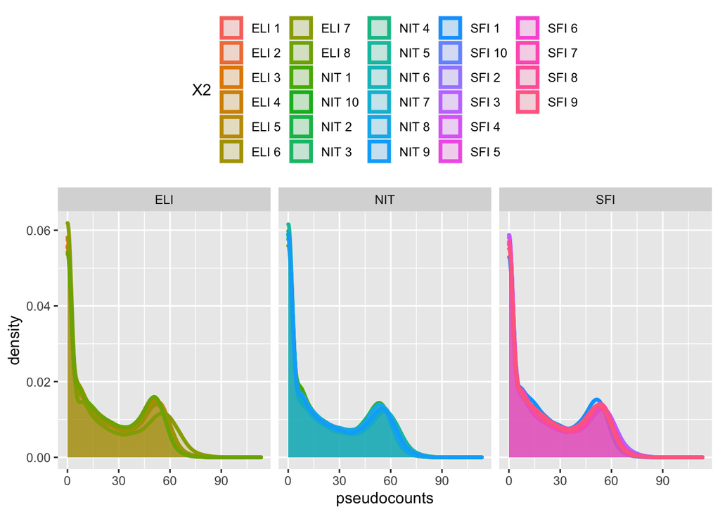

```r
ggplot(df.norm, aes(x = value, colour = X2, fill = X2, main= "Distribución de datos normalizados")) +
geom_density(alpha = 0.2, size = 1.25) + facet_wrap(~ Condition) +
theme(legend.position = "top") + xlab("pseudocounts")
```

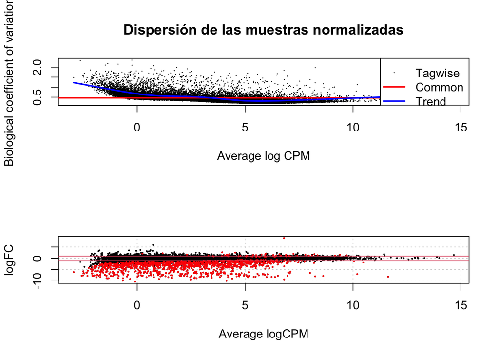

```r
#Dif expresados
designMat <- model.matrix(~group)
dgList <- estimateGLMCommonDisp(dgList, design=designMat)
dgList <- estimateGLMTrendedDisp(dgList, design=designMat)
dgList <- estimateGLMTagwiseDisp(dgList, design=designMat)
plotBCV(dgList, main= "Dispersión de las muestras normalizadas")
fit<-glmFit(dgList,designMat)

#Comparación NIT vs ELI
lrt2vs1 <- glmLRT(fit, coef=2)
edgeR_result2vs1 <- topTags(lrt2vs1)
edgeR_result2vs1
deGenes2vs1 <- decideTestsDGE(lrt2vs1, p=0.001)
deGenes2vs1 <- rownames(lrt2vs1)[as.logical(deGenes2vs1)]
plotSmear(lrt2vs1, de.tags=deGenes2vs1)
abline(h=c(-1, 1), col=2)
```

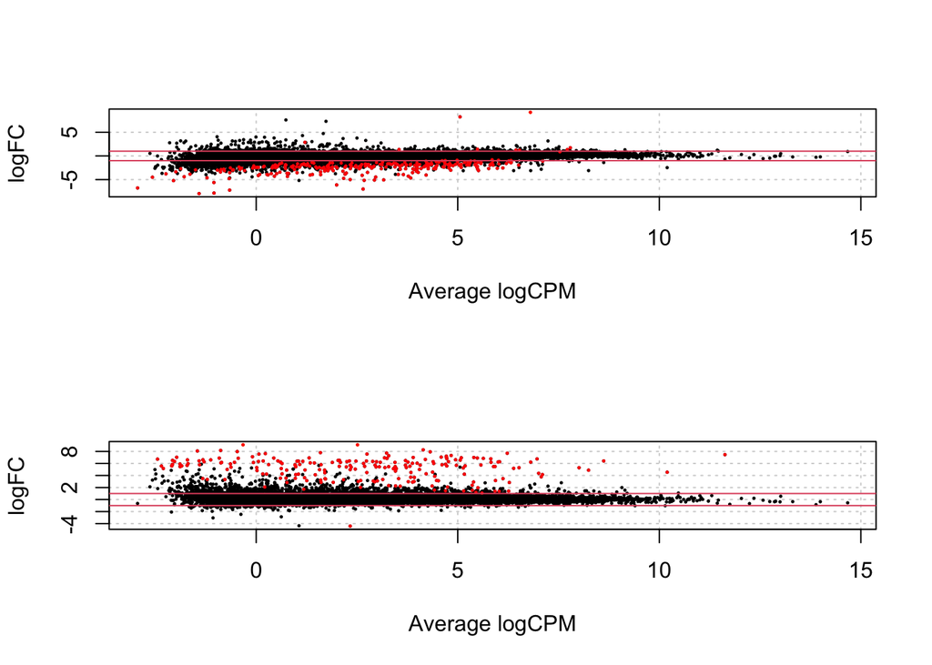

```r
#Comparación SFI vs ELI
lrt3vs1 <- glmLRT(fit, coef=3)
edgeR_result3vs1 <- topTags(lrt3vs1)
edgeR_result3vs1
deGenes3vs1 <- decideTestsDGE(lrt3vs1, p=0.001)
deGenes3vs1 <- rownames(lrt3vs1)[as.logical(deGenes3vs1)]
plotSmear(lrt3vs1, de.tags=deGenes3vs1)
abline(h=c(-1, 1), col=2)

#Comparación SFI vs NIT
lrt3vs2 <- glmLRT(fit,contrast=c(0,-1,1))
edgeR_result3vs2 <- topTags(lrt3vs2)
edgeR_result3vs2
deGenes3vs2 <- decideTestsDGE(lrt3vs2, p=0.001)
deGenes3vs2 <- rownames(lrt3vs2)[as.logical(deGenes3vs2)]
plotSmear(lrt3vs2, de.tags=deGenes3vs2)
abline(h=c(-1, 1), col=2)
```

```r
#Anot NIT vs ELI
edgeR_result2vs1$table$symbol <- mapIds(org.Hs.eg.db,
                     keys=edgeR_result2vs1$table$genes,
                     column="SYMBOL",
                     keytype="ENSEMBL",
                     multiVals="first")
edgeR_result2vs1$table$entrez <- mapIds(org.Hs.eg.db,
                     keys=edgeR_result2vs1$table$genes,
                     column="ENTREZID",
                     keytype="ENSEMBL",
                     multiVals="first")
resOrdered2vs1 <- edgeR_result2vs1[order(edgeR_result2vs1$table$PValue),]
head(resOrdered2vs1)

#Anot SFI vs ELI
edgeR_result3vs1$table$symbol <- mapIds(org.Hs.eg.db,
                     keys=edgeR_result3vs1$table$genes,
                     column="SYMBOL",
                     keytype="ENSEMBL",
                     multiVals="first")
edgeR_result3vs1$table$entrez <- mapIds(org.Hs.eg.db,
                     keys=edgeR_result3vs1$table$genes,
                     column="ENTREZID",
                     keytype="ENSEMBL",
                     multiVals="first")
resOrdered3vs1 <- edgeR_result3vs1[order(edgeR_result3vs1$table$PValue),]
head(resOrdered3vs1)

#Anot SFI vs NIT
edgeR_result3vs2$table$symbol <- mapIds(org.Hs.eg.db,
                     keys=edgeR_result3vs2$table$genes,
                     column="SYMBOL",
                     keytype="ENSEMBL",
                     multiVals="first")
edgeR_result3vs2$table$entrez <- mapIds(org.Hs.eg.db,
                     keys=edgeR_result3vs2$table$genes,
                     column="ENTREZID",
                     keytype="ENSEMBL",
                     multiVals="first")
resOrdered3vs2 <- edgeR_result2vs1[order(edgeR_result3vs2$table$PValue),]
head(resOrdered3vs2)

#Gene enrich tot
library("clusterProfiler")
listOfTables <- list(NITvsELI = edgeR_result2vs1$table, SFIvsELI = edgeR_result3vs1$table, SFIvsNIT = edgeR_result3vs2$table)
all_res<-rbind(edgeR_result2vs1$table, edgeR_result3vs1$table, edgeR_result3vs2$table)
eg.all <- enrichGO(gene         = all_res$genes,
                OrgDb         = org.Hs.eg.db,
                keyType       = 'ENSEMBL',
                ont           = "BP",
                pAdjustMethod = "fdr",
                pvalueCutoff  = 0.01,
                qvalueCutoff  = 0.05)
eg.all@result

#Gene enrich NIT vs ELI
res.2vs1<-as.data.frame(edgeR_result2vs1$table)
eg.2vs1 <- enrichGO(gene         = res.2vs1$genes,
                OrgDb         = org.Hs.eg.db,
                keyType       = 'ENSEMBL',
                ont           = "BP",
                pAdjustMethod = "fdr",
                pvalueCutoff  = 0.01,
                qvalueCutoff  = 0.05)
eg.2vs1@result

#Gene enrich SFI vs ELI
res.3vs1<-as.data.frame(edgeR_result3vs1$table)
eg.3vs1 <- enrichGO(gene         = res.3vs1$genes,
                OrgDb         = org.Hs.eg.db,
                keyType       = 'ENSEMBL',
                ont           = "BP",
                pAdjustMethod = "fdr",
                pvalueCutoff  = 0.01,
                qvalueCutoff  = 0.05)
eg.3vs1@result

#Gene enrich SFI vs NIT
res.3vs2<-as.data.frame(edgeR_result3vs2$table)
eg.3vs2 <- enrichGO(gene         = res.3vs2$genes,
                OrgDb         = org.Hs.eg.db,
                keyType       = 'ENSEMBL',
                ont           = "BP",
                pAdjustMethod = "fdr",
                pvalueCutoff  = 0.01,
                qvalueCutoff  = 0.05)
eg.3vs2@result
```

[output not shown]